# Part II - (PROSPER LOAN DATA EXPLANATORY VISUALIZATION)

## by (Gabriel Chidera Edeh)

## Investigation Overview

> The goal of this presentation will be to find out how some selected features in the dataset influence/ or is been influenced by the loan amount and prosper rating.

**The key findings include;**

> Majority of the listing and average loan requested for was for debt consolidation.

> More than half of the borrower were home owners and this set of people also topped the average loan original amount

> Highest percentage of the loan listing was carried out in the 4th quarter, followed by the 1st quarter

> Prosper rating AA which is the best rating is closly associated with low borrower rate between 0.05 and 0.10 while 25000 above loan original amount is associated with AA, A,B

## Dataset Overview

> This data set contains 113,937 loans with 81 variables on each loan, including loan amount, borrower rate (or interest rate), current loan status, borrower income, and many others

## How is IncomeRange of the borrower related to a successful loan listing?

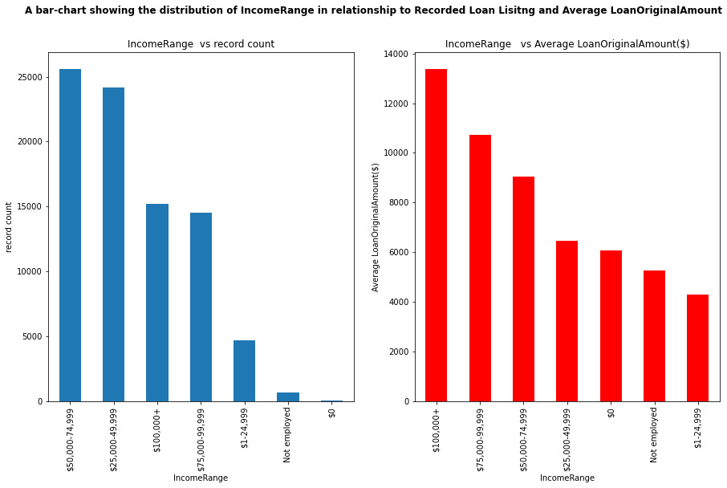

## How is the Listing Category related to the LoanOriginalAmount?

## Which Listing Category recorded the highest loan listing ?

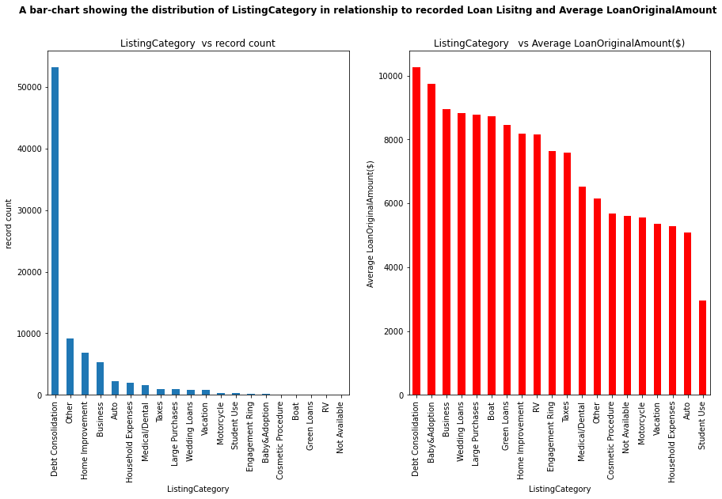

> Majority of the listing and average loan requested for was for debt consolidation.

## How does being a homeowner related to being loan listed?

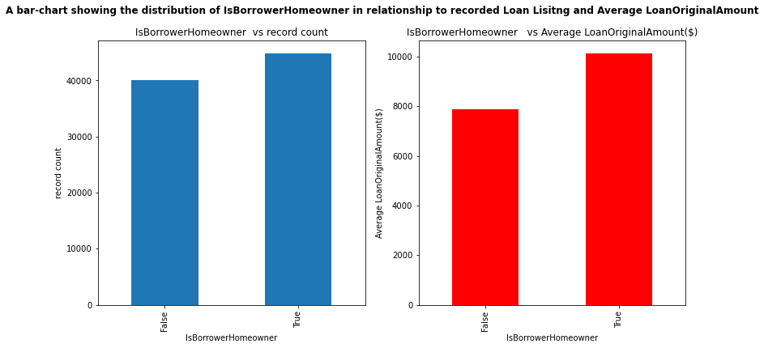

> More than half of the borrower were home owners and this set of people also topped the average loan original amount

## Which Quarter of the year recorded the highest loan listing ?

## How is the Quarter of the year distributed in terms of the Average LoanOriginalAmount?

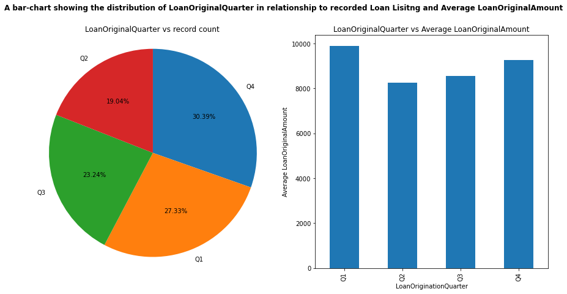

> Highest percentage of the loan listing was carried out in the 4th quarter, followed by the 1st quarter and lastly by the 2nd quarter of the year, with the 1st quarter recording the highest average loan amount for the years the survey was carried out

## How is borrower rate, Original loan amount and Prosper rating related to each other?

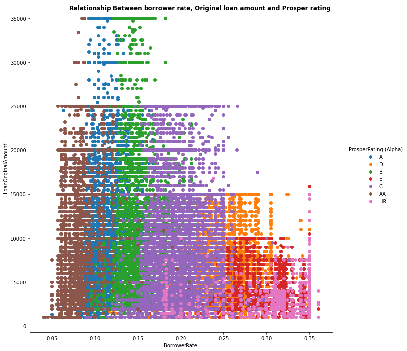

> Prosper rating AA which is the best rating is closly associated with low borrower rate between 0.05 and 0.10 while 25000 above loan original amount is associated with AA, A,B